# Interactive Visualization with Bokeh - 1

One should look for what is and not what he thinks should be. (Albert Einstein)

# Interactive Plots: Topic introduction

In this part of the course, we will cover the following concepts:

- Introduction to `bokeh`
- Organize and visualize data with `bokeh`

# Module completion checklist

| Objective | Complete |
| --- | --- |
| Explain how to create basic visualizations in bokeh |  |
| Generate a figure using Bokeh and add customized glyphs to it |  |

# Warm up

- Do you know Python has over 137000 libraries which can be helpful in creating applications in machine learning, data science, data manipulation, data visualization?
- For creating data visualizations, Python offers a large community and a vast number of built-in modules
- Take 5 minutes to read about [Top 8 Python Libraries for Data Visualization](https://www.geeksforgeeks.org/top-8-python-libraries-for-data-visualization/) and then share your thoughts on the following questions with the whole group:
  - Do you visualize data regularly at work? If yes, what do you use for creating visualizations?
  - Have you used any of the Python libraries for data visualization? Which one?

# Visualizing data with Bokeh

- `bokeh` is an interactive visualization library that targets modern web browsers for presentation
- Bokeh offers two interfaces to users:
  - **`bokeh.models`**: low-level interface with the most flexibility (most users will not use this level of interface to assemble plots directly)
  - **`bokeh.plotting`**: higher-level interface centered around composing visual glyphs
- Note: The `bokeh.plotting` interface is handy when we need to customize the output by adding more data series, glyphs, etc.

[figure not shown]

# Plotting with Bokeh

Here are the basic steps for creating plots with the `bokeh.plotting` interface:

- **Prepare data:**
  - Could be NumPy arrays or Pandas series
- Tell Bokeh **where to generate output:**
  - In this case, it’s `output_notebook()` for use in Jupyter notebooks
- **Call `figure()`**
  - This creates a plot with default options and easy customization of title, tools, and axes labels

# Plotting with Bokeh (cont’d)

- **Add renderers:**
  - Use functions specifying visual customization like colors, legends, and widths
- Ask Bokeh to **`show()` or `save()` the results:**
  - These functions save the plot to an HTML file and optionally display it in a browser
- Note: The last two steps can be repeated to create more than one plot

# Output methods using Bokeh

Here are some common methods to view Bokeh plots, such as:

- `output_file()`
  - Generates HTML documents for Bokeh visualizations
- `output_notebook()`
  - Displays inline visualizations in Jupyter notebook

# Module completion checklist

| Objective | Complete |
| --- | --- |
| Explain how to create basic visualizations in bokeh | **✔** |
| Generate a figure using Bokeh and add customized glyphs to it |  |

# Load the libraries

- Let’s import the libraries we will be using in this module

```python
import pandas as pd
import numpy as np
import os
import matplotlib.pyplot as plt

from bokeh.io import output_notebook
from bokeh.plotting import figure, output_file, show, output_notebook, save
from bokeh.transform import factor_cmap, factor_mark
from bokeh.layouts import column, row, gridplot
from bokeh.models import HoverTool, ColumnDataSource, NumeralTickFormatter, GroupFilter, CDSView
import ipywidgets as widgets
from ipywidgets import interact, interact_manual
```

# Bokeh: simple plot

- At first, we will create simple plots using data points assigned to variables `x_values` and `y_values`

```python
# Input the sample data below.
x_values = [1, 2, 3, 4, 5, 6]
y_values = [6, 7, 2, 3, 6, 4]
```

# Bokeh: simple plot

Steps to create a simple plot:

1. Make a plot using the `figure()` method
2. Append the glyphs to the plot by calling an appropriate method and passing in data
3. Show the plot

[figure not shown]

```python
# Set the output method
output_notebook()

p = figure()
p.circle(x = x_values, y = y_values)
show(p)
```

# Bokeh: add size, color, and opacity

- We can also modify the same circle glyph by adding functions with a specific size, color, and alpha

[figure not shown]

```python
# Create the blank plot.
p = figure(width = 400, height = 400)

# Add a circle glyph with a size, color, and alpha.
p.circle(x_values,
         y_values,
         size = 20,
         color = "red",
         alpha = 0.7)
show(p)
```

# Bokeh: triangle glyph

- Further, we can add two different glyphs to the graph

[figure not shown]

```python
p = figure(width = 400, height = 400)

p.line(x_values,
       y_values,
       color = 'red')

p.triangle(x_values,
           y_values,
           size = 20,
           color = "darkseagreen",
           alpha = 0.7)
show(p)
```

# Bokeh: marker types

- A glyph is a vectorized graphical shape or marker that is used to represent your data
- There are a lot of marker types you can try out
- [Click here](https://docs.bokeh.org/en/2.4.1/docs/reference/models/markers.html) to see examples of plots with different markers

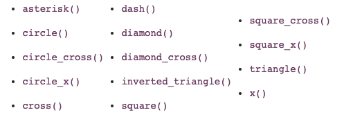

# Knowledge check

# Module completion checklist

| Objective | Complete |
| --- | --- |
| Explain how to create basic visualizations in bokeh | **✔** |
| Generate a figure using Bokeh and add customized glyphs to it | **✔** |

# Congratulations on completing this module!

You are now ready to try tasks 1-2 in the Exercise for this topic